# Wind Turbine Project

Marc-Eloi NICOD

2023-10-13

# Wind Turbine project

## 1) Data description

The project is based on the iot data made publicly available by Engie for 1 wind turbine in France in La Haute Borne with data from January 2013 to January 2018 collected with a frequency of 10 minutes. Link: https://opendata-renewables.engie.com/explore/index (warning: Engie’s ‘open data page’ is not always up-and-running, but all the necessary info is also included in the shared documents.)

The data set has been enriched with certain additional parameters such as snowfall_1h, rainfall_1h, air density, humidity etc. This ‘enrichment’ was performed using historic data bought from https://openweathermap.org/

## 2) Introduction

The aim of this project is to predict the production of Power in Kw of one of the wind turbine named R80711 using weather parameters.

Two models will be developed.

The developed models should predict the power generated of wind turbines based on different weather parameters. The metric used to evaluate the performance is the RMSE (root mean squared error), which should be minimized. The models will be based on the wind turbines data set that contains 261812 observations, which will be split into two parts: The training set, used for training and evaluation of the model,and the test set, which will be used to evaluate the final model.

## 3) Methods

The first part of the report consists of an exploratory data analysis of the data set. This analysis is required to identify variables which can be used to optimize the model.

The second part of the report consists of the creation of the prediction system.

To ensure the integrity of our training and testing datasets and to mitigate the potential for data leakage due to the close temporal proximity of observations (10 minutes between observations), we will employ a time-based split rather than a random shuffle. The wind turbine dataset will be arranged chronologically based on timestamps. The first 80% of the chronologically ordered data will be designated as the training dataset, while the remaining 20% will be set aside as the test dataset. This ensures that the training data and testing data come from distinct periods, reducing the risk of unintentionally training the model on information that would be found in the test set.

For the first model, the dataset will be processed using the Min-Max Normalization to normalize the features. Subsequently, the XGBoostRegressor will be employed to predict the power generated by the wind turbine based on the weather parameters identified during exploratory data analysis. In contrast, the second model will again utilize the Min-Max Normalization for normalization but will leverage the LightGBM for predictions. In the third phase of the project, the efficacy of both models will be tested on the validation set to evaluate their performance in estimating wind turbine power output.  
We will also use cross validation to tune hyper parameter of XGBoostRegressor.

## 4) Executive summary:

In a thorough analysis, we ascertained that weather parameters effectively forecast power output with the LightGBM and XGBoost models, displaying normalized RMSEs of 69% and 71% respectively. Yet, while observed weather data was consistent, transitioning to weather forecasts may bring in uncertainties that can impact predictions. Even with these nuances, this research highlights the potential of machine learning in advancing renewable energy forecasting.

## 5) Exploratory Data Analysis and cleaning

We start with a exploratory analysis of the wind_turbine data set to identify variables which can be used to optimize the model.

| Date_time | Date_time_nr | Wind_turbine_name | Ba_avg | P_avg | Q_avg | Ya_avg | Yt_avg | Ws1_avg | Ws2_avg | Ws_avg | Wa_avg | Va_avg | Ot_avg | Rs_avg | Rbt_avg | Rm_avg | temp | pressure | humidity | wind_speed | wind_deg | rain_1h | snow_1h |
| --- | --- | --- | --- | --- | --- | --- | --- | --- | --- | --- | --- | --- | --- | --- | --- | --- | --- | --- | --- | --- | --- | --- | --- |
| 2013-01-01T00:00:00+01:00 | 1356994800 | R80711 | -1.00 | 1072.65 | 14.49 | 161.44 | 12.73 | 8.770001 | 9.160000 | 8.960000 | 165.25 | 3.78 | 5.09 | 17.18 | 28.71 | 5690.28 | 5.39 | 1011 | 75 | 5.66 | 180 | 0 | 0 |
| 2013-01-01T00:10:00+01:00 | 1356995400 | R80711 | -1.00 | 1061.43 | 23.70 | 161.44 | 14.99 | 8.660000 | 9.120000 | 8.890000 | 168.29 | 6.90 | 5.26 | 17.17 | 28.70 | 5632.72 | 5.39 | 1011 | 75 | 5.66 | 180 | 0 | 0 |
| 2013-01-01T00:20:00+01:00 | 1356996000 | R80711 | -1.00 | 1144.79 | 25.48 | 161.44 | 21.75 | 8.940000 | 9.450000 | 9.190000 | 170.08 | 8.63 | 5.56 | 17.18 | 28.79 | 6071.69 | 5.39 | 1011 | 75 | 5.66 | 180 | 0 | 0 |
| 2013-01-01T00:30:00+01:00 | 1356996600 | R80711 | -1.00 | 1183.98 | 24.38 | 173.41 | 23.80 | 8.870000 | 8.979999 | 8.920000 | 175.33 | -2.60 | 5.70 | 17.18 | 28.86 | 6279.47 | 5.39 | 1011 | 75 | 5.66 | 180 | 0 | 0 |
| 2013-01-01T00:40:00+01:00 | 1356997200 | R80711 | -0.98 | 1317.55 | 14.47 | 177.90 | 17.91 | 9.440000 | 9.510000 | 9.479999 | 173.07 | -4.78 | 5.82 | 17.18 | 28.77 | 6988.57 | 5.39 | 1011 | 75 | 5.66 | 180 | 0 | 0 |
| 2013-01-01T00:50:00+01:00 | 1356997800 | R80711 | -0.97 | 1282.11 | 11.61 | 177.90 | 13.70 | 9.370000 | 9.440000 | 9.410000 | 172.39 | -5.56 | 5.80 | 17.17 | 28.70 | 6801.85 | 5.39 | 1011 | 75 | 5.66 | 180 | 0 | 0 |

The dataset consists of 24 variables with 261812 observations.

The dataset contains the following variables:“Date_time”, “Date_time_nr”, “Wind_turbine_name”, “Ba_avg”, “P_avg”, “Q_avg”, “Ya_avg”, “Yt_avg”, “Ws1_avg”, “Ws2_avg”, “Ws_avg”, “Wa_avg”, “Va_avg”, “Ot_avg”, “Rs_avg”, “Rbt_avg”, “Rm_avg”, “temp”, “pressure”, “humidity”, “wind_speed”, “wind_deg”, “rain_1h”, and “snow_1h”. For our analysis, we will focus on the weather-related variables we added, using them to predict the power output represented by “P_avg”.

Let’s verify if there is some missing values or NA:

```r
missing_values <- apply(is.na(wind_turbine), 2, sum)

cat(missing_values)
```

```
## 0 0 0 0 0 0 0 0 0 0 0 0 0 0 0 0 0 0 0 0 0 0 0 0
```

As we can see there is no missing values.

Let’s check columns names:

```r
cat(colnames(wind_turbine))
```

```
## Date_time Date_time_nr Wind_turbine_name Ba_avg P_avg Q_avg Ya_avg Yt_avg Ws1_avg Ws2_avg Ws_avg Wa_avg Va_avg Ot_avg Rs_avg Rbt_avg Rm_avg temp pressure humidity wind_speed wind_deg rain_1h snow_1h
```

Let’s see what are our weather parameters values using histograms:

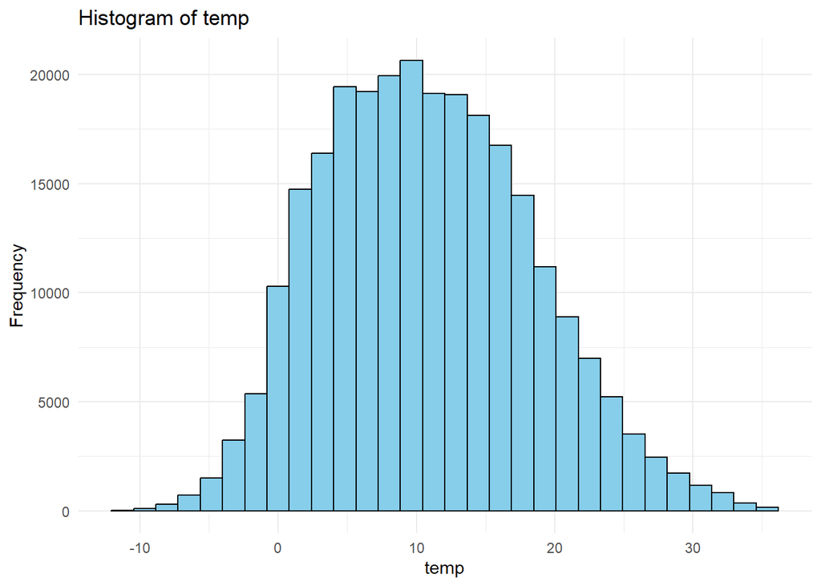

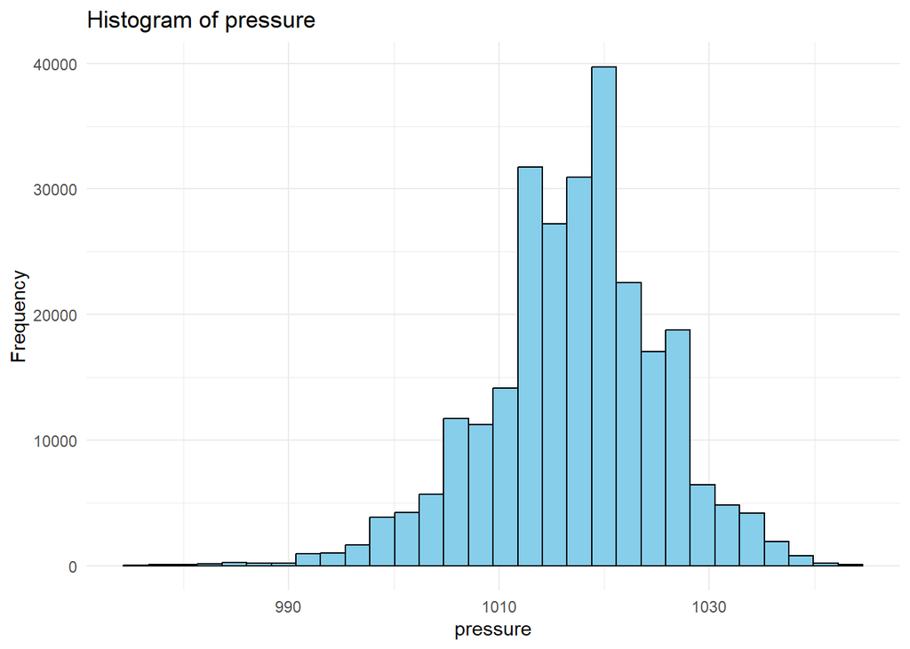

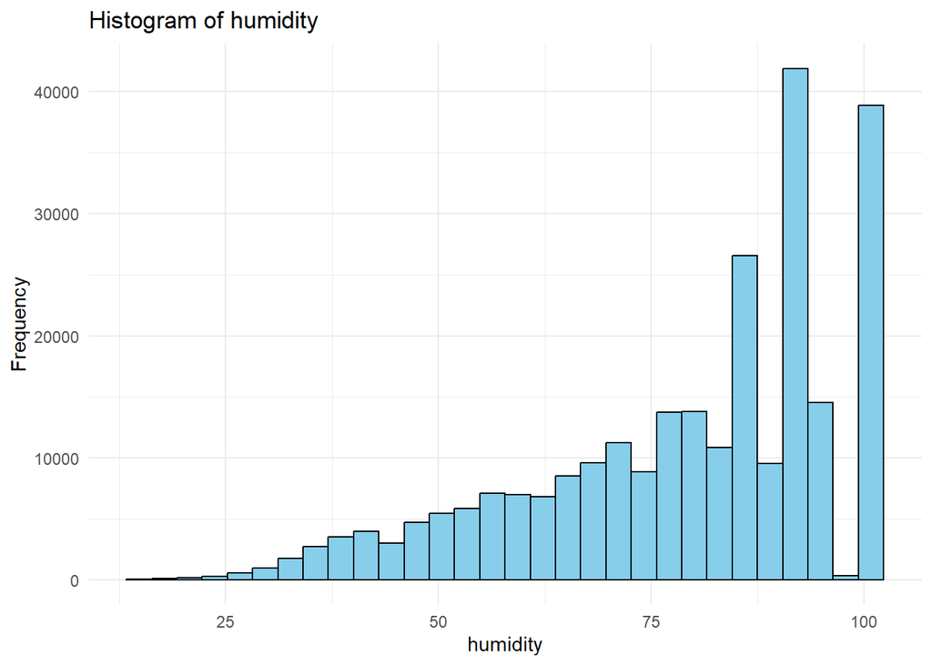

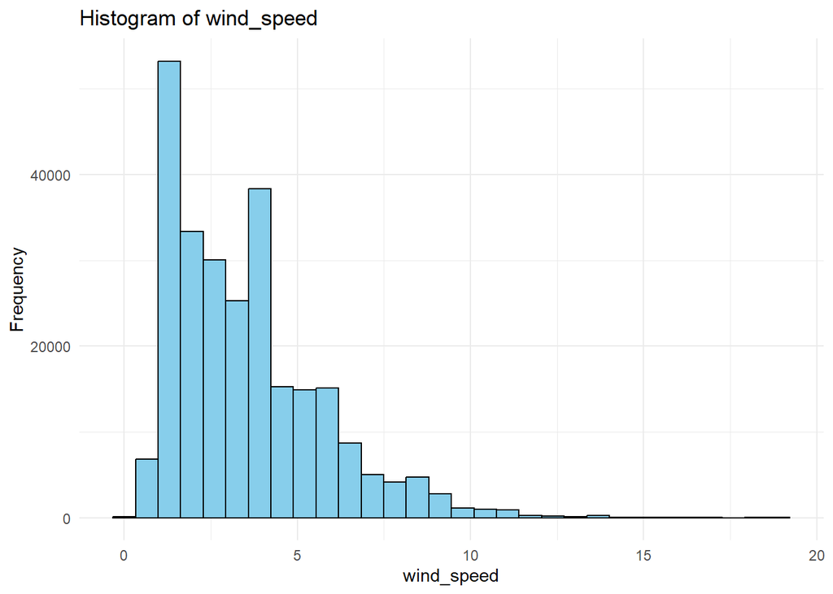

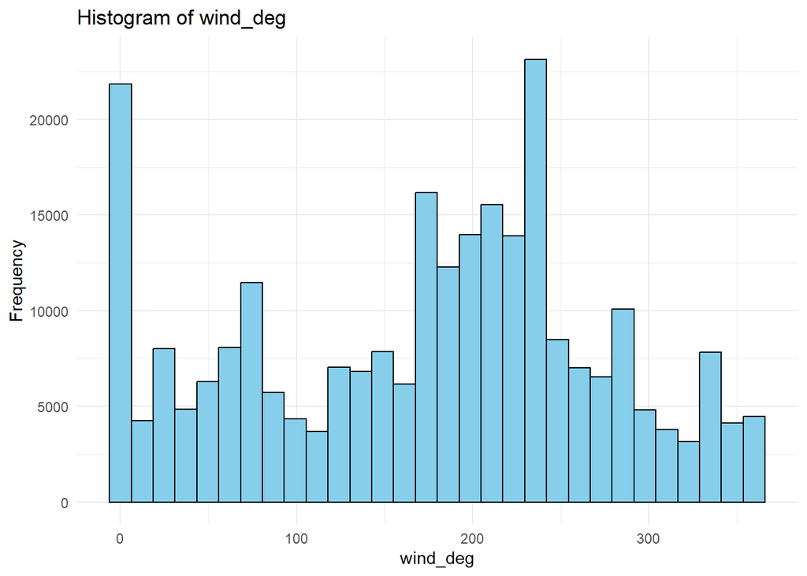

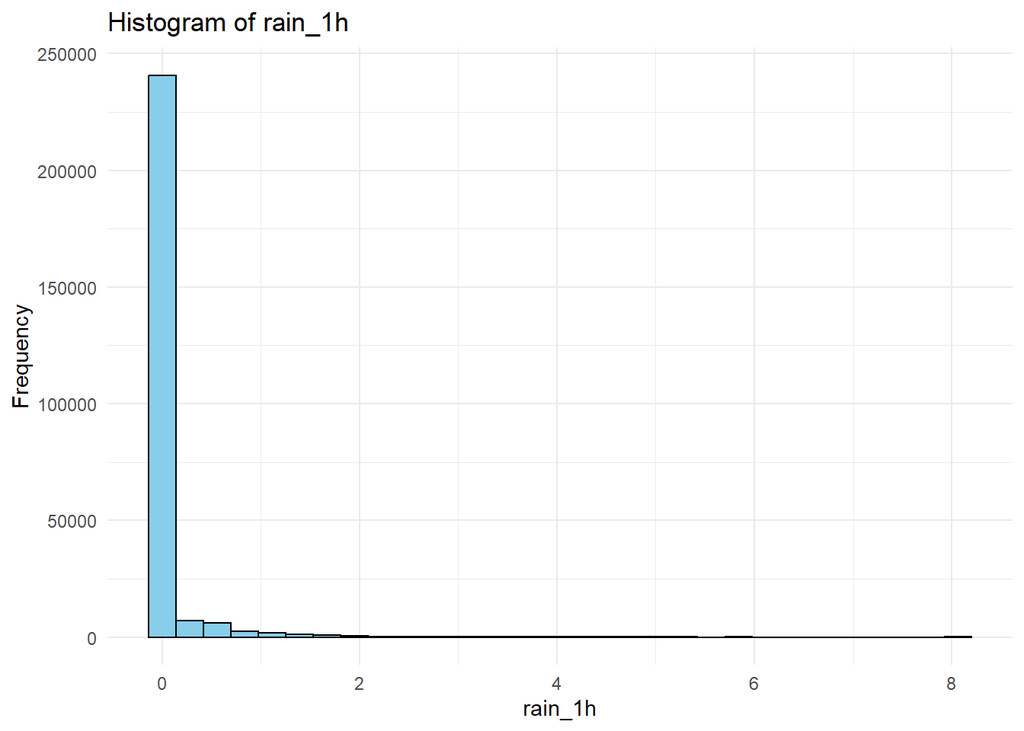

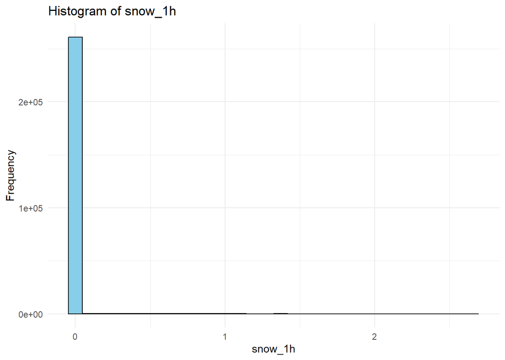

From the histograms above, no significant patterns stand out. Let’s now focus on the relationship between power generated by wind turbines and wind speed, as it’s likely our primary correlation:

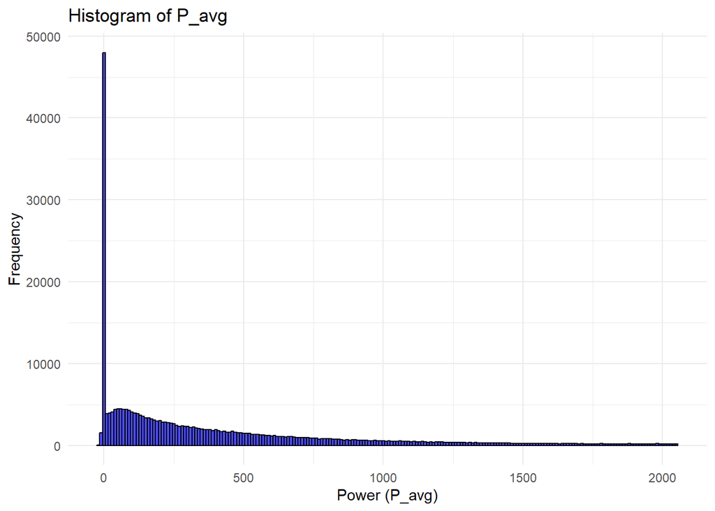

From this histogram, it seems that there is some negative value for Power output. As it’s not possible, we know can remove some negative (impossible) value and check again the same plot with our new data set cleaned “wind_turbine_clean_1”.  
I will also remove 0 values from the plot for more visibility:

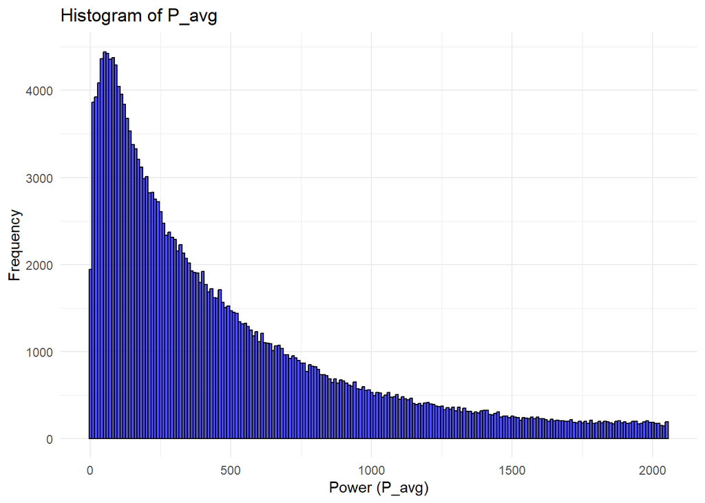

```r
library(dplyr)

wind_turbine_clean_1 <- wind_turbine %>%
  filter(P_avg >= 0)

wind_turbine_clean_1 %>%
  filter(P_avg > 0) %>%
  ggplot(aes(x = P_avg)) +
  geom_histogram(binwidth = 10, fill = "blue", color = "black", alpha = 0.7) +
  labs(title = "Histogram of P_avg", x = "Power (P_avg)", y = "Frequency") +
  theme_minimal()
```

**Wind speed effect on Power output:**

Of course wind speed will have an important effect on the power generated. Let’s plot it:

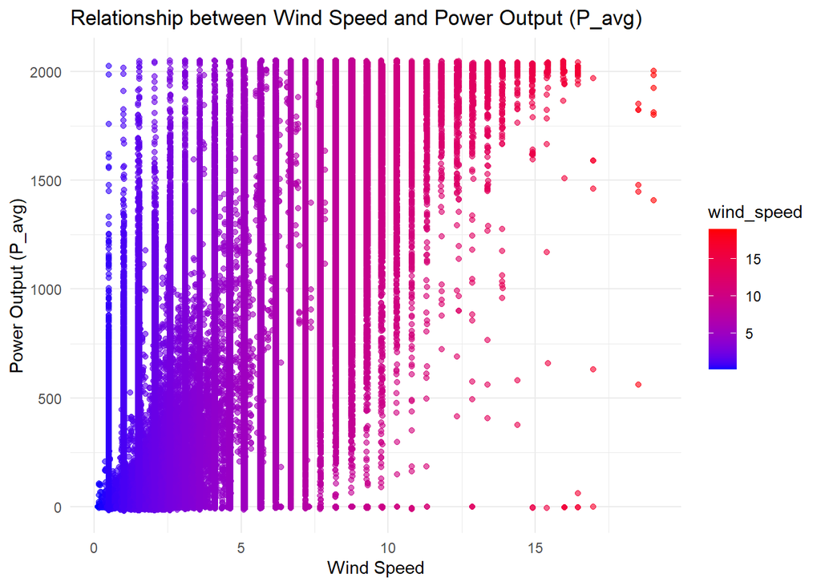

From the graph above we can see clearly a pattern between wind speed and power output.  
I propose to visualize also with a graph showing the density of points so it may be more clean to see the pattern:

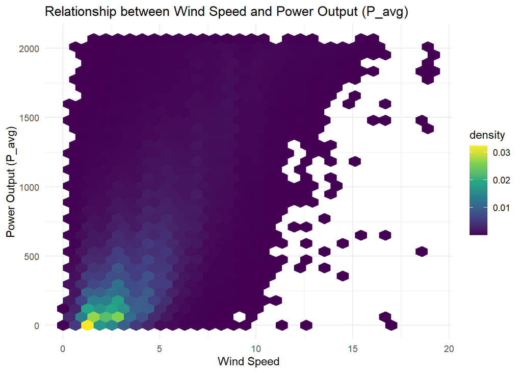

Let’s create similar visualizations for the other weather variables: temperature, pressure, humidity, wind direction, rainfall in the last hour, and snowfall in the last hour

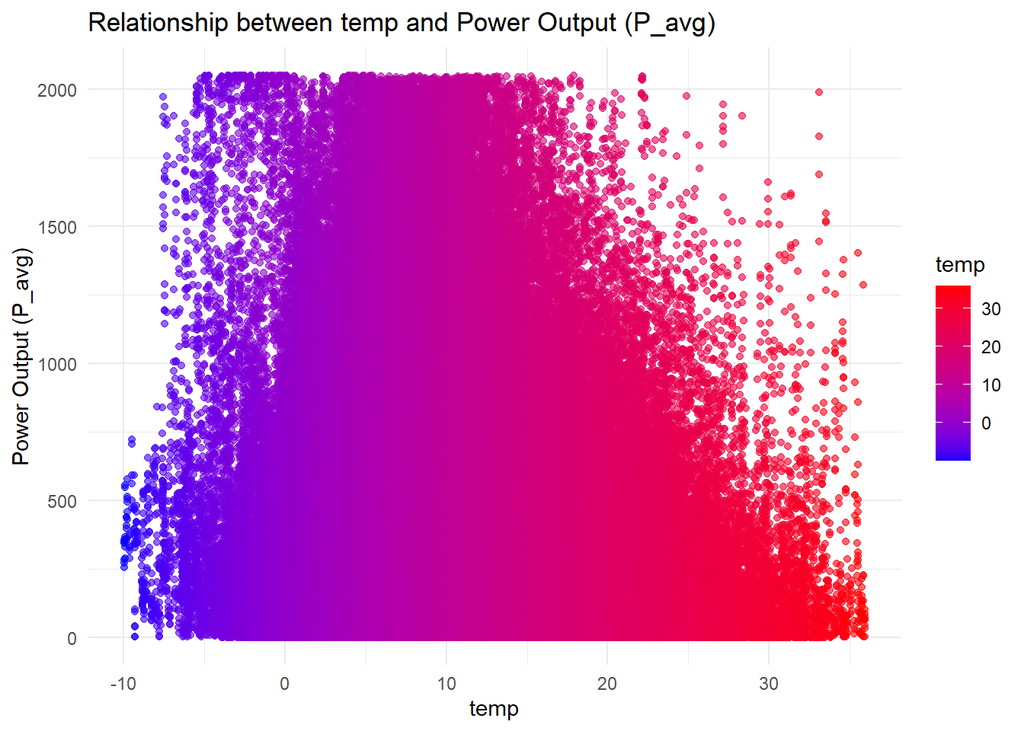

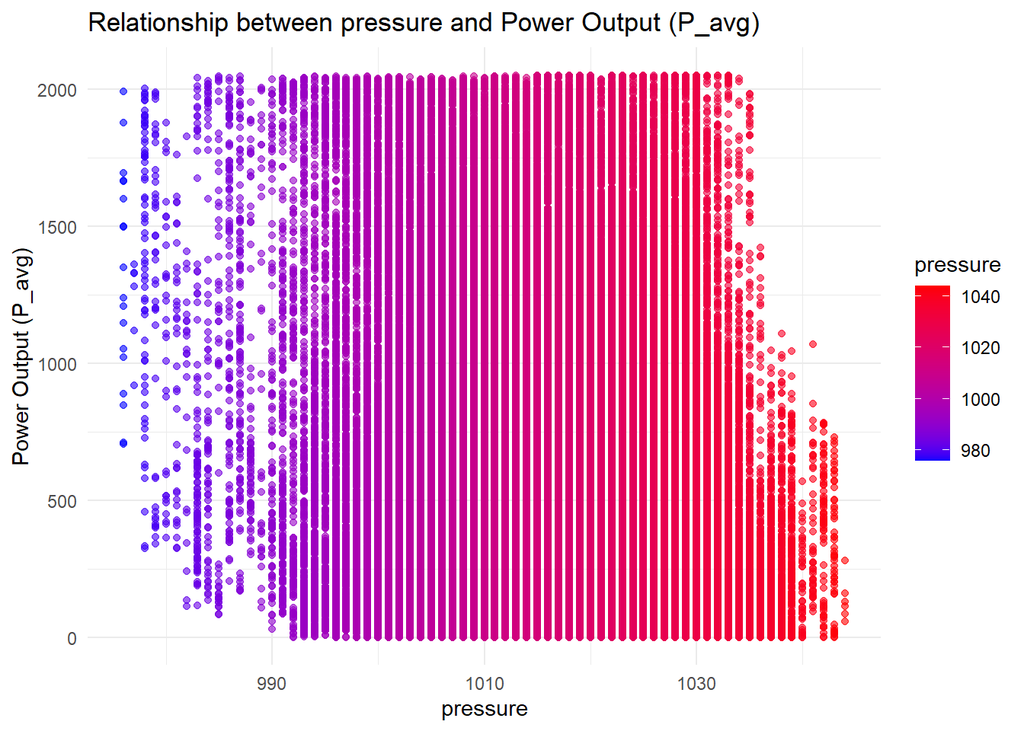

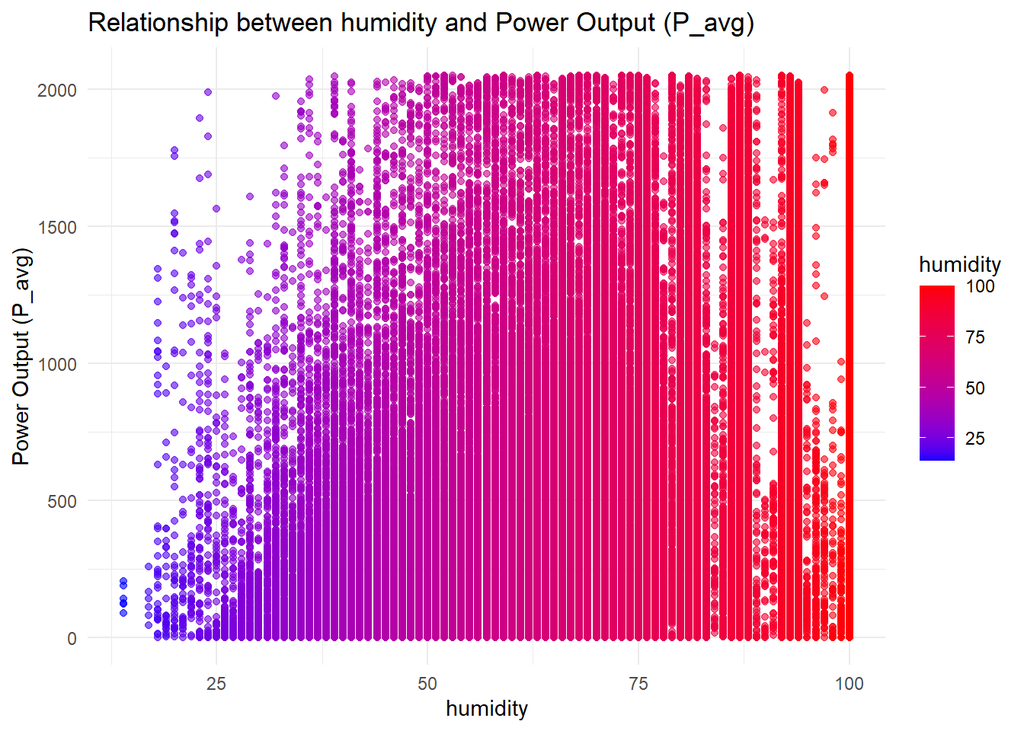

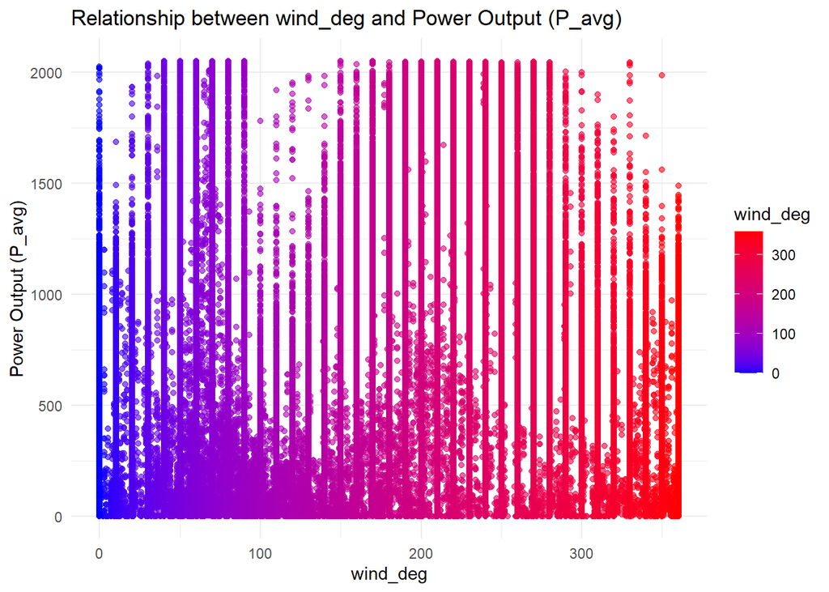

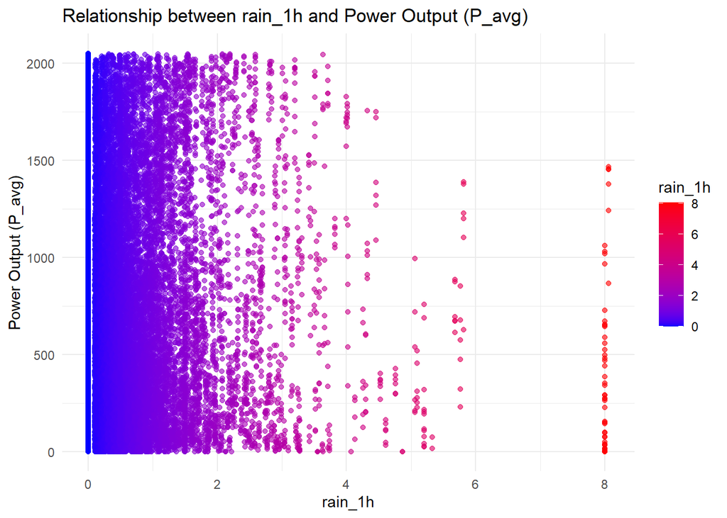

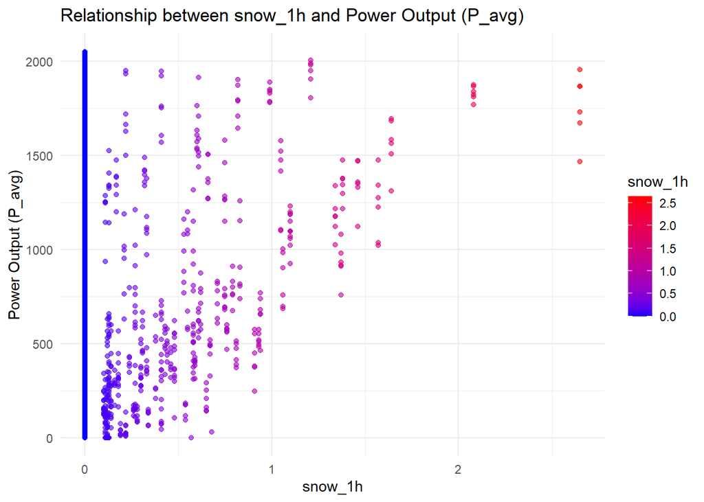

## 6) Modelisation

In our analysis, we chose to utilize the XGBoost and LightGBM algorithms, primarily because both are renowned for their efficiency and accuracy in handling regression tasks, especially with large datasets. They are gradient boosting frameworks that employ tree-based learning algorithms and have proven to deliver state-of-the-art results across various domains.

The normalization of data, specifically using the range method, is a crucial pre-processing step. Normalization rescales the features so that they fall within a given range, usually [0, 1]. This ensures that no particular feature exerts undue influence on the model due to its scale. In datasets where features have different units or vary widely in magnitudes, models can become biased, or take longer to train. By normalizing, we ensure that the optimization algorithms (like gradient descent) used in these machine learning algorithms converge faster, and the models become more sensitive to the actual patterns in the data rather than being influenced by the scales of the features.

```r
library(xgboost)
library(lightgbm)
library(caret)
library(Metrics)
# Sort the data chronologically
wind_turbine_clean_1 <- wind_turbine_clean_1 %>% arrange(Date_time)

# Split the data
train_index <- 1:floor(0.8 * nrow(wind_turbine_clean_1))
train_data <- wind_turbine_clean_1[train_index, ]
test_data <- wind_turbine_clean_1[-train_index, ]

# Define predictor variables and target
predictors <- c("temp", "pressure", "humidity", "wind_speed", "wind_deg", "rain_1h", "snow_1h")
target <- "P_avg"

# Normalize using Min-Max Normalization from the caret package
preProcValues <- preProcess(train_data[, predictors], method = c("range"))
train_data_normalized <- predict(preProcValues, train_data[, predictors])
test_data_normalized <- predict(preProcValues, test_data[, predictors])

# Prepare data for XGBoost
dtrain <- xgb.DMatrix(data = as.matrix(train_data_normalized), label = train_data[[target]])
dtest <- xgb.DMatrix(data = as.matrix(test_data_normalized), label = test_data[[target]])

# Hyperparameter tuning for XGBoost
xgb_params_list <- list(
  list(eta = 0.01, max_depth = 4, objective = "reg:linear"),
  list(eta = 0.1, max_depth = 4, objective = "reg:linear"),
  list(eta = 0.3, max_depth = 4, objective = "reg:linear"),
  list(eta = 0.01, max_depth = 6, objective = "reg:linear"),
  list(eta = 0.1, max_depth = 6, objective = "reg:linear"),
  list(eta = 0.3, max_depth = 6, objective = "reg:linear")
)

best_model <- NULL
best_cv_error <- Inf

for (params in xgb_params_list) {
  cv_model <- xgb.cv(params = params, data = dtrain, nfold = 5, nrounds = 100, early_stopping_rounds = 10, verbose = 0)
  min_error <- min(cv_model$evaluation_log$test_rmse_mean)

  if (min_error < best_cv_error) {
    best_cv_error <- min_error
    best_model <- cv_model
    best_param <- params
  }
}
```

[output not shown]

```r
# Train the XGBoost model using the best parameters
xgb_model <- xgb.train(params = best_param, data = dtrain, nrounds = 100)
```

```
## [13:08:00] WARNING: src/objective/regression_obj.cu:213: reg:linear is now deprecated in favor of reg:squarederror.
```

```r
xgb_predictions <- predict(xgb_model, dtest)

# Prepare data for LightGBM
dtrain_lgb <- lgb.Dataset(data = as.matrix(train_data_normalized), label = train_data[[target]])

# Train the LightGBM model:
lgb_model <- lgb.train(data = dtrain_lgb, objective = "regression", nrounds = 100)
```

```
## [LightGBM] [Warning] Auto-choosing col-wise multi-threading, the overhead of testing was 0.006227 seconds.
## You can set `force_col_wise=true` to remove the overhead.
## [LightGBM] [Info] Total Bins 1139
## [LightGBM] [Info] Number of data points in the train set: 178352, number of used features: 7
## [LightGBM] [Info] Start training from score 466.702473
```

```r
lgb_predictions <- predict(lgb_model, data = as.matrix(test_data_normalized))

# Evaluation
evaluate_model <- function(true_values, predictions) {
  residuals <- true_values - predictions
  sse <- sum(residuals^2)
  sst <- sum((true_values - mean(true_values))^2)
  r2 <- 1 - (sse/sst)

  list(
    RMSE = rmse(true_values, predictions),
    R2 = r2,
    MAE = mae(true_values, predictions),
    Normalized_RMSE = rmse(true_values, predictions) / mean(true_values),
    Normalized_MAE = mae(true_values, predictions) / mean(true_values)
  )
}

xgb_evaluation <- evaluate_model(test_data[[target]], xgb_predictions)
lgb_evaluation <- evaluate_model(test_data[[target]], lgb_predictions)

cat("Evaluation for XGBoost:\n")
```

```
## Evaluation for XGBoost:
```

```r
print(xgb_evaluation)
```

```
## $RMSE
## [1] 303.3752
##
## $R2
## [1] 0.5921549
##
## $MAE
## [1] 225.7298
##
## $Normalized_RMSE
## [1] 0.7099123
##
## $Normalized_MAE
## [1] 0.5282183
```

```r
cat("\nEvaluation for LightGBM:\n")
```

```
##
## Evaluation for LightGBM:
```

```r
print(lgb_evaluation)
```

```
## $RMSE
## [1] 295.9379
##
## $R2
## [1] 0.6119066
##
## $MAE
## [1] 222.472
##
## $Normalized_RMSE
## [1] 0.6925087
##
## $Normalized_MAE
## [1] 0.5205949
```

```r
# After generating the xgb_predictions
test_data$xgb_predictions <- xgb_predictions

# After generating the lgb_predictions
test_data$lgb_predictions <- lgb_predictions
```

## 7) Metrics:

**XGBoost Model Evaluation:**

**RMSE (Root Mean Squared Error):** 303

This metric gives an idea of the magnitude of error our model makes in its predictions. A lower RMSE indicates a better fit of the model to the data. An RMSE of 303 means that, on average, our predictions deviate from the actual values by about 303 Kw.

**R^2 (Coefficient of Determination):** 0.59 (or 59%)

R^2 measures the proportion of variance in the dependent variable that is predictable from the independent variables. An R^2 of 59% suggests that the model explains approximately 59% of the variability in the power output.

**MAE (Mean Absolute Error):** 226

MAE represents the average absolute error between the true and predicted values. An MAE of 226 indicates that, on average, the model’s predictions are off by about 226 Kw.

**Normalized RMSE:** 71%

**Normalized MAE:** 53%

**LightGBM Model Evaluation:**

**RMSE (Root Mean Squared Error):** 296

The LightGBM model has a slightly lower RMSE than XGBoost, meaning its predictions are, on average, closer to the actual values by about 296 Kw.

**R^2 (Coefficient of Determination):** 0.61 (or 61%)

The model explains approximately 61% of the variability in the power output, which is slightly better than the XGBoost model.

**MAE (Mean Absolute Error):** 222

On average, the model’s predictions are off by about 222 Kw, which is slightly better than the XGBoost model.

**Normalized RMSE:** 69%

**Normalized MAE:** 52%

**Summary:** Both models demonstrate commendable predictive abilities. However, the LightGBM model, with an RMSE of 296, has a slight edge over the XGBoost model, which has an RMSE of 303, across every metric assessed. Notably, the elevated errors, particularly in the normalized metrics, suggest room for enhancement and optimization. Exploring additional features, adjusting model parameters, or considering alternative modeling strategies might further elevate their performance.

Let’s plot the predicted power generated by day versus the power really generated:

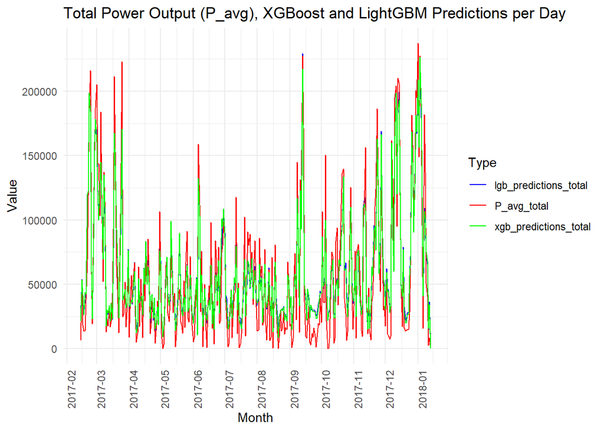

```r
library(tidyr)

# Convert Date_time to Date format, then group by Date and aggregate P_avg
aggregated_data <- test_data %>%
  mutate(Date = as.Date(Date_time)) %>%
  group_by(Date) %>%
  summarise(P_avg_total = sum(P_avg),
            xgb_predictions_total = sum(xgb_predictions),
            lgb_predictions_total = sum(lgb_predictions))  # Added for LightGBM predictions

# Convert to long format for ggplot2
aggregated_data_long <- aggregated_data %>%
  gather(key = "Type", value = "Value", P_avg_total, xgb_predictions_total, lgb_predictions_total)

# Plot using ggplot2 with every month labeled on the x-axis
ggplot(aggregated_data_long, aes(x = Date, y = Value, color = Type)) +
  geom_line() +
  labs(title = "Total Power Output (P_avg), XGBoost and LightGBM Predictions per Day",
       x = "Month",
       y = "Value") +
  theme_minimal() +
  scale_x_date(date_breaks = "1 month", date_labels = "%Y-%m") +
  theme(axis.text.x = element_text(angle = 90, hjust = 1)) +
  scale_color_manual(values = c("blue", "red", "green"))
```

## 8) Conclusion

Through diligent analysis and modeling using advanced machine learning algorithms, namely XGBoost and LightGBM, we have successfully demonstrated that weather parameters can be a robust predictor of power output. Both models yielded satisfactory results, validating our hypothesis that meteorological conditions play a significant role in influencing power output.

However, it’s pivotal to approach this conclusion with a degree of caution. Our models were trained and tested using observed weather data, which inherently is accurate and precise. When transitioning from observed data to weather forecasts for prediction, the inherent uncertainties and potential inaccuracies of meteorological predictions could introduce additional challenges. Predictive weather data, while continually improving, is not flawless and carries its inherent prediction errors. Thus, while our current models showcase the viability of using weather parameters for power output prediction, the performance might be somewhat attenuated when using weather forecasts instead of observations.

Nonetheless, this project serves as a strong foundation, highlighting the potential of leveraging machine learning techniques in the realm of renewable energy. As weather prediction technology advances and becomes more accurate, the efficacy of such models will only further improve, paving the way for more sustainable and predictable energy production.